# Statistical Computing - TR

## Data Analiz Raporu

[RÜZGAR ÜREN →](https://ruzgaruren.blogspot.com/)

13 06 2021

[Dr. Zeynep Filiz Eren Doğu →](https://www.mu.edu.tr/tr/personel/zferendogu)

```r
library(vcd)
library(plyr)
library(ggplot2)
library(dplyr)
library(car)
library(psych)
```

Verileri yükleme işlemleri

```r
kisirlastirilan <- read.csv("kisirlastirilan.csv")
muayene <- read.csv("muayene.csv")
mudahale <- read.csv("müdehale.csv")
knitr::opts_chunk$set(echo = TRUE)
```

Kısırlaştırılan sokak hayvanları veri setindeki değişkenlerin türünü değiştirme işlemleri

```r
#Karakter->Factor
kisirlastirilan$ILCE<-as.factor(kisirlastirilan$ILCE)
#Karakter->Factor
kisirlastirilan$MAHALLE<-as.factor(kisirlastirilan$MAHALLE)
#Karakter->Factor
kisirlastirilan$KISIRLASTIRILAN_HAYVAN_NOKTALARI<-as.factor(kisirlastirilan$KISIRLASTIRILAN_HAYVAN_NOKTALARI)
#Integer->Factor
kisirlastirilan$YIL<-as.factor(kisirlastirilan$YIL)
#Integer->Factor
kisirlastirilan$AY<-as.factor(kisirlastirilan$AY)
```

Muayene ve Müdahale edilen sokak hayvanlarını karşılaştırmak için veri birleştirme işlemleri

```r
a <- cbind(muayene$YIL,muayene$AY,muayene$ADET,mudahale$ADET)
Birlestirilmis.Veri <- data.frame(a)
```

Birlestirilmis verideki değişkenlere isim atama işlemleri

```r
names(Birlestirilmis.Veri)[1] <- "Yil"
names(Birlestirilmis.Veri)[2] <- "Ay"
names(Birlestirilmis.Veri)[3] <- "Muayene_Adedi"
names(Birlestirilmis.Veri)[4] <- "Mudahale_Adedi"
```

Birleştirilmiş verideki yıl değişkenini integerden factor değişkenine çevirme işlemi

```r
#Integer->Factor
Birlestirilmis.Veri$Yil<-as.factor(Birlestirilmis.Veri$Yil)
```

# Veri Görselleştirme ve Tanımlayıcı İstatistikler

Her yıl için ayrı ayrı sokak hayvanlarına ait muayene ve müdahale sayıları arasındaki ilişkiyi grafik üzerinden inceleyelim.

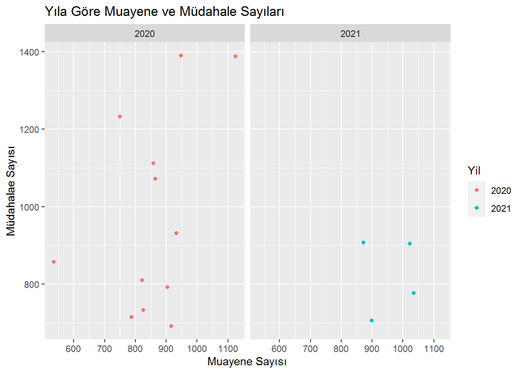

```r
ggplot(Birlestirilmis.Veri,aes(Muayene_Adedi,Mudahale_Adedi, color=Yil)) +
  geom_point() +
  facet_wrap(~Yil)+
  xlab("Muayene Sayısı") +
  ylab("Müdahalae Sayısı") +
  ggtitle("Yıla Göre Muayene ve Müdahale Sayıları")
```

Bu grafige göre 2020 yılında sokak hayvanlarına yapılan müdahale adeti 2021 yılında sokak hayvanlarına yapılan müdahale adetinden daha fazladır.

#### Kısırlaştırılan sokak hayvanları veri setini ilçeye ve adete göre bar grafigi üzerinde inceleyelim.

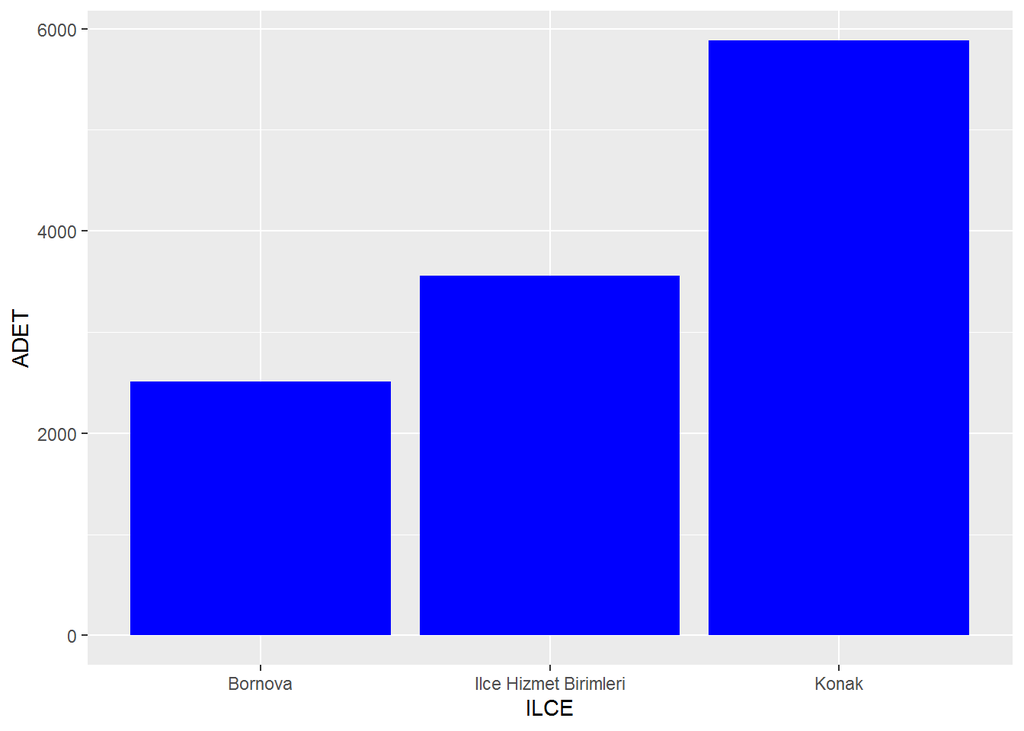

```r
ggplot(kisirlastirilan,aes(x=ILCE,y=ADET))+geom_bar(stat = "identity",fill="Blue")
```

Bar grafigine göre en çok Konak’da en az ise Bornova’da sokak hayvanı kısırlaştırılmıştır.

Tüm veri setlerine ait tanımlayıcı istatiskleri inceleyelim.

```r
describe(kisirlastirilan)
```

|  | vars | n | mean | sd | median | trimmed | mad | min | max | range | skew | kurtosis | se |
| --- | --- | --- | --- | --- | --- | --- | --- | --- | --- | --- | --- | --- | --- |
| ï.._id | 1 | 36 | 18.500000 | 10.5356538 | 18.5 | 18.500000 | 13.3434 | 1 | 36 | 35 | 0.0000000 | -1.3003629 | 1.75594229 |
| YIL* | 2 | 36 | 1.333333 | 0.4780914 | 1.0 | 1.300000 | 0.0000 | 1 | 2 | 1 | 0.6778496 | -1.5821759 | 0.07968191 |
| AY* | 3 | 36 | 5.166667 | 3.5010203 | 4.0 | 4.933333 | 2.9652 | 1 | 12 | 11 | 0.5523729 | -1.0620352 | 0.58350338 |
| ILCE* | 4 | 36 | 2.000000 | 0.9561829 | 2.0 | 2.000000 | 1.4826 | 1 | 3 | 2 | 0.0000000 | -1.9366319 | 0.15936381 |
| MAHALLE* | 5 | 36 | 2.333333 | 0.6761234 | 2.0 | 2.400000 | 1.4826 | 1 | 3 | 2 | -0.4793120 | -0.8732639 | 0.11268723 |
| KISIRLASTIRILAN_HAYVAN_NOKTALARI* | 6 | 36 | 2.333333 | 0.6761234 | 2.0 | 2.400000 | 1.4826 | 1 | 3 | 2 | -0.4793120 | -0.8732639 | 0.11268723 |
| ADET | 7 | 36 | 331.916667 | 239.9795676 | 275.0 | 293.433333 | 183.1011 | 88 | 990 | 902 | 1.3726460 | 1.0772361 | 39.99659460 |

```r
describe(muayene)
```

|  | vars | n | mean | sd | median | trimmed | mad | min | max | range | skew | kurtosis | se |
| --- | --- | --- | --- | --- | --- | --- | --- | --- | --- | --- | --- | --- | --- |
| ï.._id | 1 | 16 | 8.50 | 4.7609523 | 8.5 | 8.500000 | 5.9304 | 1 | 16 | 15 | 0.0000000 | -1.4262408 | 1.1902381 |
| YIL | 2 | 16 | 2020.25 | 0.4472136 | 2020.0 | 2020.214286 | 0.0000 | 2020 | 2021 | 1 | 1.0481569 | -0.9492187 | 0.1118034 |
| AY | 3 | 16 | 5.50 | 3.6147845 | 4.5 | 5.357143 | 3.7065 | 1 | 12 | 11 | 0.3810880 | -1.3479784 | 0.9036961 |
| FAALIYET_TURU* | 4 | 16 | 1.00 | 0.0000000 | 1.0 | 1.000000 | 0.0000 | 1 | 1 | 0 | NaN | NaN | 0.0000000 |
| ADET | 5 | 16 | 880.75 | 133.0671510 | 885.5 | 888.000000 | 91.1799 | 535 | 1125 | 590 | -0.6163413 | 0.8343873 | 33.2667877 |

```r
describe(mudahale)
```

|  | vars | n | mean | sd | median | trimmed | mad | min | max | range | skew | kurtosis | se |
| --- | --- | --- | --- | --- | --- | --- | --- | --- | --- | --- | --- | --- | --- |
| ï.._id | 1 | 16 | 8.500 | 4.7609523 | 8.5 | 8.500000 | 5.9304 | 1 | 16 | 15 | 0.0000000 | -1.4262408 | 1.1902381 |
| YIL | 2 | 16 | 2020.250 | 0.4472136 | 2020.0 | 2020.214286 | 0.0000 | 2020 | 2021 | 1 | 1.0481569 | -0.9492187 | 0.1118034 |
| AY | 3 | 16 | 5.500 | 3.6147845 | 4.5 | 5.357143 | 3.7065 | 1 | 12 | 11 | 0.3810880 | -1.3479784 | 0.9036961 |
| FAALIYET_TURU* | 4 | 16 | 1.000 | 0.0000000 | 1.0 | 1.000000 | 0.0000 | 1 | 1 | 0 | NaN | NaN | 0.0000000 |
| ADET | 5 | 16 | 938.625 | 233.7958868 | 880.5 | 924.000000 | 232.0269 | 692 | 1390 | 698 | 0.7725182 | -0.8391488 | 58.4489717 |

# Güven Aralığı

Muayene edilen sokak hayvanları veri setindeki adet değişkeninin güven aralığını inceleyelim. Bunun için adet değişkenine ait ortalama ve standart sapmayı da hesaplayalım.

```r
n=16
muayene_adet_ort=mean(muayene$ADET)
muayene_adet_sd=sd(muayene$ADET)
cbind(muayene_adet_ort,muayene_adet_sd)
```

```
##      muayene_adet_ort muayene_adet_sd
## [1,]           880.75        133.0672
```

```r
error <- qnorm(0.975)*muayene_adet_sd/sqrt(n)
alt_sinir <- muayene_adet_ort-error
üst_sinir <- muayene_adet_ort+error
cbind(alt_sinir,üst_sinir)
```

```
##      alt_sinir üst_sinir
## [1,]  815.5483  945.9517
```

Adet değişkeninin ortalaması 880 olarak, %95 güven aralığı ise [815-945] olarak bulunmuşur. Yani 100 kere tekrarlanan işlemin 95’inde ortalama [815-945] aralığında değişim göstermektedir.

Müdahale edilen sokak hayvanları veri setindeki adet değişkeninin güven aralığını inceleyelim. Bunun için adet değişkenine ait ortalama ve standart sapmayı da hesaplayalım.

```r
n=16
mudahale_adet_ort=mean(mudahale$ADET)
mudahale_adet_sd=sd(mudahale$ADET)
cbind(mudahale_adet_ort,mudahale_adet_sd)
```

```
##      mudahale_adet_ort mudahale_adet_sd
## [1,]           938.625         233.7959
```

```r
error <- qnorm(0.975)*mudahale_adet_sd/sqrt(n)
alt_sinir <- mudahale_adet_ort-error
üst_sinir <- mudahale_adet_ort+error
cbind(alt_sinir,üst_sinir)
```

```
##      alt_sinir üst_sinir
## [1,]  824.0671  1053.183
```

Adet değişkeninin ortalaması 938 olarak, %95 güven aralığı ise [824-1053] olarak bulunmuşur. Yani 100 kere tekrarlanan işlemin 95’inde ortalama [824-1053] aralığında değişim göstermektedir.

# Hipotez Testleri

## Kısırlaştırılan sokak hayvanları veri setindeki kısırlaştırılan hayvan noktası ve yıl arasında ilişki olup olmadığını inceleyelim.

H0:Kısırlastırılan hayvan noktası ve yıl arasında ilişki yoktur. H1:Kısırlaştırılan hayvan noktası ve yıl arasında ilişki vardır.

Bunun için ki-kare testi kullanalım.

```r
ct=table(kisirlastirilan$KISIRLASTIRILAN_HAYVAN_NOKTALARI,kisirlastirilan$YIL)
print(ct)
```

```
##
##                                             2020 2021
##                                                0    4
##   Isikkent- seyrek Kopek Bakimevi             12    4
##   Veteriner isleri Kucuk Hayvan poliklinigi   12    4
```

```r
chisq.test(ct)
```

```
##
##  Pearson's Chi-squared test
##
## data:  ct
## X-squared = 9, df = 2, p-value = 0.01111
```

```r
assocstats(ct)
```

```
##                     X^2 df  P(> X^2)
## Likelihood Ratio 9.8396  2 0.0073007
## Pearson          9.0000  2 0.0111090
##
## Phi-Coefficient   : NA
## Contingency Coeff.: 0.447
## Cramer's V        : 0.5
```

Yapılan ki-kare analizi sonucuna göre p<0,05’den küçük çıkmıştır. H0 reddedilir.Yani kısırlaştırılan hayvan noktaları ve yıl arasında ilişki vardır.Bu ilişkinin gücü Cramer’s V = 0,5 olarak bulunmuştur. Ancak çapraz tabloda 5’den küçük değerler olduğu için bu test sonucu çok da güvenilir değildir.

Muayene ve Müdehale edilen sokak hayvanlarının ortalamaları arasında anlamlı bir farklılık olup olmadığını inceleyelim.

H0: Muayene ve müdehale edilen sokak hayvanları arasında anlamlı farklılık yoktur. H1: Muayene ve müdehale edilen sokak hayvanları arasında anlamlı farklılık vardır.

Bunun için bağımsız örneklem t-testini kullanalım.

```r
#Normallik Testi
shapiro.test(muayene$ADET)
```

```
##
##  Shapiro-Wilk normality test
##
## data:  muayene$ADET
## W = 0.94158, p-value = 0.3688
```

```r
shapiro.test(mudahale$ADET)
```

```
##
##  Shapiro-Wilk normality test
##
## data:  mudahale$ADET
## W = 0.86977, p-value = 0.02698
```

```r
#Varyans Homojenliği Testi
birlestirilmis.degisken=c(muayene$ADET,mudahale$ADET)
muayene.uzunluk =length(muayene$ADET)
mudahale.uzunluk=length(mudahale$ADET)
muayene.belirtec=rep(1,muayene.uzunluk)
mudahale.belirtec=rep(2,mudahale.uzunluk)
bileske.belirtec=c(muayene.belirtec,mudahale.belirtec)
test = leveneTest(birlestirilmis.degisken,bileske.belirtec)
print(test)
```

```
## Levene's Test for Homogeneity of Variance (center = median)
##       Df F value  Pr(>F)
## group  1  3.6298 0.06638 .
##       30
## ---
## Signif. codes:  0 '***' 0.001 '**' 0.01 '*' 0.05 '.' 0.1 ' ' 1
```

```r
#Bağımsız Örneklem T Testi
ttest=t.test(muayene$ADET,mudahale$ADET,var.equal = TRUE)
if(ttest$p.value<0.05) {
  print("Muayene ve müdehale edilen sokak hayvanları arasında anlamlı farklılık vardır.")
  print(ttest)
} else {
  print("Muayene ve müdehale edilen sokak hayvanları arasında anlamlı farklılık yoktur.")
  print(ttest)
}
```

```
## [1] "Muayene ve müdehale edilen sokak hayvanları arasında anlamlı farklılık yoktur."
##
##  Two Sample t-test
##
## data:  muayene$ADET and mudahale$ADET
## t = -0.86056, df = 30, p-value = 0.3963
## alternative hypothesis: true difference in means is not equal to 0
## 95 percent confidence interval:
##  -195.22388   79.47388
## sample estimates:
## mean of x mean of y
##   880.750   938.625
```

Bağımsız örneklem t testi yapılabilmesi için gerekli ön koşullar vardır. Bunlardan biri verilerin normal dağılım göstermesi diğeri ise varyansların homojen olmasıdır. Verilerin shapiro-wilk testi ile dağılımları incelendiğinde muayene verisine ait adet değişkenin normal dağılım gösterdiği (p>0,05), mudahale değişkenine ait adet değişkeninin normal dağılım göstermediği (p<0,05) görülmüştür.(Ancak bu test geregi her iki değişkenin de normal dağılım gösterdiği kabul edilmiştir.) Varyans homojenligi koşulunun sağlanıp sağlanmadıgı incelemek için Levene testi yapılmıştır.Yapılan Levene testi sonucunda varyans homojenligi koşulunun sağlandığı görülmüştür (p>0,05). Ön koşulların test edilmesinin ardından yapılan t testi sonucunda muayene ve müdehale edilen sokak hayvanları arasında anlamlı farklılık olmadığı görülmüştür (p>0,05).Yani H0 kabul edilmiştir.

## Kısırlaştırılan sokak hayvanları adetlerinin ilçeye göre farklılık gösterip göstermediğini inceleyelim.

H0: Kısırlaştırılan sokak hayvanları adetleri ilçeye göre farklılık göstermemektedir. H1: Kısırlaştırılan sokak hayvanları adetleri ilçeye göre farklılık göstermektedir.

Bunun için tek yönlü ANOVA testini kullanalım.

```r
#Normallik Testi
shapiro.test(kisirlastirilan$ADET)
```

```
##
##  Shapiro-Wilk normality test
##
## data:  kisirlastirilan$ADET
## W = 0.81832, p-value = 3.845e-05
```

```r
#Varyans Homojenligi Testi
leveneTest(kisirlastirilan$ADET,kisirlastirilan$ILCE)
```

|  | Df | F value | Pr(>F) |
| --- | --- | --- | --- |
| group | 2 | 4.044369 | 0.02685676 |
|  | 33 | NA | NA |

```r
#Tek Yönlü ANOVA Testi
anova = aov(ADET~ILCE, data = kisirlastirilan)
summary(anova)
```

```
##             Df  Sum Sq Mean Sq F value Pr(>F)
## ILCE         2 1756469  878235   111.8  2e-15 ***
## Residuals   33  259188    7854
## ---
## Signif. codes:  0 '***' 0.001 '**' 0.01 '*' 0.05 '.' 0.1 ' ' 1
```

Tek yönlü anova testinin yapılabilmesi için gerekli ön koşullar bulunmaktadır. Bunlardan biri verilerin normal dağılım göstermesi diğeri ise varyansların homojen olmasıdır. Bu ön koşullar incelediğinden verilerin normal dağılım göstermediği(p<0,05) ve varyans homojenliği koşulunun sağlanmadıgı(p<0,05) görülmüştür.(Ancak bu test geregi verilerin normal dağılım gösterdiği ve varyans homojenliği koşulunun sağlandıgı kabul edilmiştir.)

Ön koşulların incelenmesinin ardından yapılan anova testi sonucunda kısırlaştırılan hayvan adetlerinin ilçeye göre anlamlı farklılık gösterdiği görülmüştür (p<0,05).Yani H0 reddedilir.

Bu farklılığın hangi ilçelerden kaynaklandığını incelemek için Bonferroni ikili karşılaştırma testi kullanılmıştır.

```r
ikili.karsilastirma = pairwise.t.test(kisirlastirilan$ADET, kisirlastirilan$ILCE,
                                      p.adjust.method = "bonferroni",
                                      pool.sd = FALSE)
print(ikili.karsilastirma)
```

```
##
##  Pairwise comparisons using t tests with non-pooled SD
##
## data:  kisirlastirilan$ADET and kisirlastirilan$ILCE
##
##                       Bornova Ilce Hizmet Birimleri
## Ilce Hizmet Birimleri 0.0026  -
## Konak                 2.1e-06 0.0029
##
## P value adjustment method: bonferroni
```

Bonferroni karşılaştırması sonucunda kısırlaştırılan hayvan adetleri ortalamalarının, tüm ilçelerde birbirinden farklı oldugu görülmüştür.

# ANOVA veya Regresyon

## Kısırlaştırılan sokak hayvanları adetlerinin aylara göre farklılık gösterip göstermediğini inceleyelim.

H0: Kısırlaştırılan sokak hayvanları adetleri aya göre farklılık göstermemektedir. H1: Kısırlaştırılan sokak hayvanları adetleri aya göre farklılık göstermektedir.

Bunun için tek yönlü ANOVA testini kullanalım.

```r
#Normallik Testi
shapiro.test(kisirlastirilan$ADET)
```

```
##
##  Shapiro-Wilk normality test
##
## data:  kisirlastirilan$ADET
## W = 0.81832, p-value = 3.845e-05
```

```r
#Varyans Homojenligi Testi
leveneTest(kisirlastirilan$ADET,kisirlastirilan$AY)
```

|  | Df | F value | Pr(>F) |
| --- | --- | --- | --- |
| group | 11 | 0.4674282 | 0.905442 |
|  | 24 | NA | NA |

```r
#Tek Yönlü ANOVA Testi
anova.sonucu = aov(ADET~AY, data = kisirlastirilan)
summary(anova.sonucu)
```

```
##             Df  Sum Sq Mean Sq F value Pr(>F)
## AY          11  354682   32244   0.466  0.906
## Residuals   24 1660975   69207
```

Tek yönlü anova testinin yapılabilmesi için gerekli ön koşullar bulunmaktadır. Bunlardan biri verilerin normal dağılım göstermesi diğeri ise varyansların homojen olmasıdır. Bu ön koşullar incelediğinde verilerin normal dağılım göstermediği(p<0,05) Ancak varyans homojenligi koşulunun sağlandıgı(p>0,05) görülmüştür.(Bu test geregi verilerin normal dağılım gösterdiği kabul edilmiştir.)

Ön koşulların incelenmesinin ardından yapılan anova testi sonucunda kısırlaştırılan hayvan adetlerinin aya göre anlamlı farklılık göstermediği görülmüştür (p>0,05).Yani H0 kabul edilir.

### 1107090006

### MUĞLA SITKI KOÇMAN ÜNİVERSİTESİ

### LECTURER: Dr. ZEYNEP FİLİZ EREN DOĞU